# A review for stock time series problem based on LSTM (Tensorflow)

### THU, Computer Science Department, E-mail: alex.holla@foxmail.com

**Abstracts:** Many blog writers have published the articles about using LSTM to solve stock time series problem. But there are several common shortcomings. In this article, I will talk about the details both in experiments and programmings. And I want to use it in equity trading. If you both have some experience and interest in this fields, please feel free to contact me.

1.They just show the codes and not do individual experiments to show the differences. Some peopel did so, because they don't know it clearly. Some people did so just to save time. But it's not good for new beginner. **Many new beginner will just read it and it's hard for them to start their first projects.**

2.Many of them ignore some **experiments details**, to be honest, details is everything, especially in deep learning field.

3.Some of them ignores the **programming details**, here I mean the specific settings in tensorflow. If you use keras or caffe, I strongly reconmmand you to use tensorflow or pytorch,which push you to figure out the exact network details.

## 1.Easy tasks with low level of noise

At the very begining, let's try to solve a very simple problem. Which is to use LSTM learn the transformation from sin(x) to cos(x). This question exactly has no noise at all. So we don't need to think about the overfitting problem. Let's just write a write LSTM structure to deal with it.

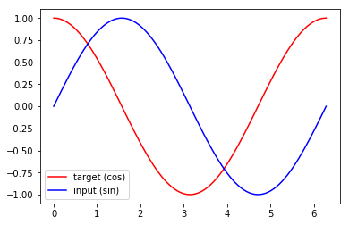

```python
#data
import tensorflow as tf
import numpy as np
import matplotlib.pyplot as plt

steps = np.linspace(0, np.pi*2, 100, dtype=np.float32)
x_np = np.sin(steps)
y_np = np.cos(steps)
plt.plot(steps, y_np, 'r-', label='target (cos)')
plt.plot(steps, x_np, 'b-', label='input (sin)')
plt.legend(loc='best')
plt.show()
```

### 1.1 LSTM: for each time, we input 10 points and predict 10 points

```python
TIME_STEP =  10       # rnn time step
INPUT_SIZE = 1      # rnn input size
CELL_SIZE = 64      # rnn cell size
LR = 0.02           # learning rate

tf.reset_default_graph()
tf_x = tf.placeholder(tf.float32, [None, TIME_STEP, INPUT_SIZE])        # shape(batch, 5, 1)
tf_y = tf.placeholder(tf.float32, [None, TIME_STEP, INPUT_SIZE])          # input y

lstm_cell = tf.contrib.rnn.BasicLSTMCell(num_units=CELL_SIZE)
init_s = lstm_cell.zero_state(batch_size=1, dtype=tf.float32)    # very first hidden state
outputs, final_s = tf.nn.dynamic_rnn(
    lstm_cell,                   # cell you have chosen
    tf_x,                       # input
    initial_state=init_s,       # the initial hidden state
    time_major=False,           # False: (batch, time step, input); True: (time step, batch, input)
)
outs2D = tf.reshape(outputs, [-1, CELL_SIZE])                       # reshape 3D output to 2D for fully connected layer
net_outs2D = tf.layers.dense(outs2D, INPUT_SIZE)
outs = tf.reshape(net_outs2D, [-1, TIME_STEP, INPUT_SIZE])          # reshape back to 3D

loss = tf.losses.mean_squared_error(labels=tf_y, predictions=outs)  # compute cost
train_op = tf.train.AdamOptimizer(LR).minimize(loss)

sess = tf.Session()
sess.run(tf.global_variables_initializer())     # initialize var in graph
```

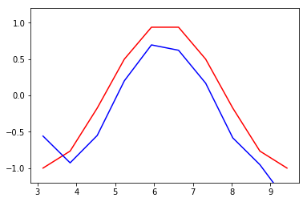

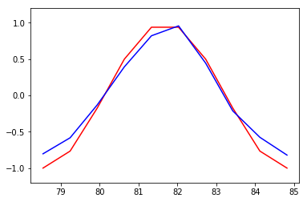

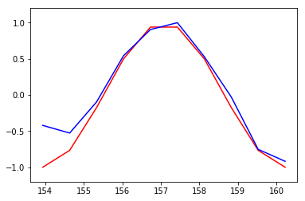

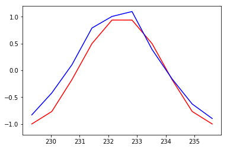

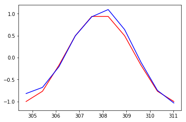

```python
#visualize the results:
for step in range(100):
    start, end = step * np.pi, (step+2)*np.pi   # time range
    # use sin predicts cos
    steps = np.linspace(start, end, TIME_STEP)
    x = np.sin(steps)[np.newaxis, :, np.newaxis]    # shape (batch, time_step, input_size)
    y = np.cos(steps)[np.newaxis, :, np.newaxis]

    #every time, you train 0-2pi.
    if step==0:                 # first state, no any hidden state
        feed_dict = {tf_x: x, tf_y: y}
    else:                                           # has hidden state, so pass it to rnn
        feed_dict = {tf_x: x, tf_y: y, init_s: final_s_}
    _, pred_, final_s_ = sess.run([train_op, outs, final_s], feed_dict)     # train

    # plotting
    if (step-1)%24==0:
        plt.plot(steps, y.flatten(), 'r-')
        plt.plot(steps, pred_.flatten(), 'b-')
        plt.ylim((-1.2, 1.2))
        plt.show()
```

### 1.2 LSTM: for each time, we input 10 points and predict 1 points

```python
TIME_STEP =  10       # rnn time step
INPUT_SIZE = 1      # rnn input size
CELL_SIZE = 64      # rnn cell size
LR = 0.02           # learning rate

tf.reset_default_graph()
tf_x = tf.placeholder(tf.float32, [None, TIME_STEP, INPUT_SIZE])        # shape(batch, 5, 1)
tf_y = tf.placeholder(tf.float32, [None, 1])          # input y

lstm_cell = tf.contrib.rnn.BasicLSTMCell(num_units=CELL_SIZE)
init_s = lstm_cell.zero_state(batch_size=1, dtype=tf.float32)    # very first hidden state
outputs, final_s = tf.nn.dynamic_rnn(
    lstm_cell,                   # cell you have chosen
    tf_x,                       # input
    initial_state=init_s,       # the initial hidden state
    time_major=False,           # False: (batch, time step, input); True: (time step, batch, input)
)
outs2D = tf.reshape(outputs, [-1, CELL_SIZE])                       # reshape 3D output to 2D for fully connected layer
l2 = tf.layers.dense(outs2D, INPUT_SIZE)
l3 = tf.reshape(l2, [-1, TIME_STEP])
outs = tf.layers.dense(l3, 1)

loss = tf.losses.mean_squared_error(labels=tf_y, predictions=outs)  # compute cost
train_op = tf.train.AdamOptimizer(LR).minimize(loss)

sess = tf.Session()
sess.run(tf.global_variables_initializer())     # initialize var in graph
```

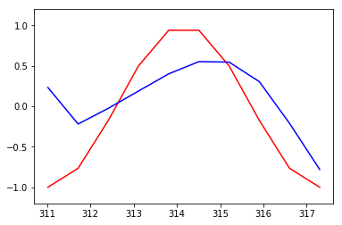

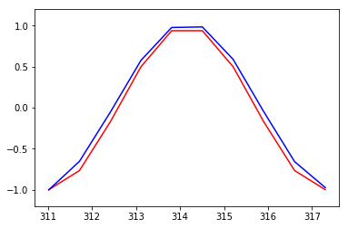

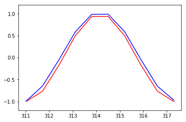

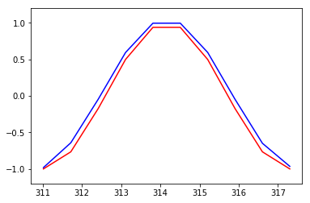

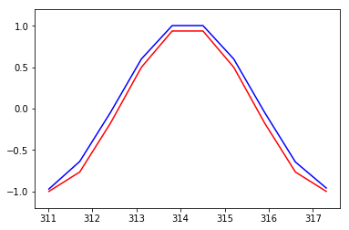

```python
#visualize the results:
for step in range(100):
    start_x, end_x = step * np.pi, (step+4)*np.pi   # time range\
    start_y, end_y = step * np.pi, (step+2)*np.pi   # time range
    # use sin predicts cos
    steps_x = np.linspace(start_x, end_x, TIME_STEP*2)
    steps_y = np.linspace(start_y, end_y, TIME_STEP)
    x = np.sin(steps_x).reshape(-1,TIME_STEP*2)
    y = np.cos(steps_y).reshape(-1,TIME_STEP)

    #every time, we only predict 1 point. Thus, we should predict 10 times to completely repeated the process mentioned above.
    print_y=[]
    for i in range(10):
        xx=x[:,i:i+10]
        yy=y[:,i]
        if step==0:                 # first state, no any hidden state
            feed_dict = {tf_x: xx.reshape(-1,TIME_STEP,1), tf_y: yy.reshape(-1,1)}
        else:                       # has hidden state, so pass it to rnn
            feed_dict = {tf_x: xx.reshape(-1,TIME_STEP,1), tf_y: yy.reshape(-1,1), init_s: final_s_}

        _, pred_, final_s_ = sess.run([train_op, outs, final_s], feed_dict)     # train
        print_y.append(pred_[0])

    # plotting
    if (step-1)%24==0:
        plt.plot(steps, y.flatten(), 'r-')
        plt.plot(steps, print_y, 'b-')
        plt.ylim((-1.2, 1.2))
        plt.show()
```

It seems that the latter one can provide more information and it's a bargin. However, for LSTM and RNN. Sometimes, we should rely on the fitting on sequence to sequence. 10 points to 10 points may provide 'more information' for the learner to learn this method. The learner will not suck in some **fake equlibrium**.

What is **fake equlibrium**? Sometimes, you think you get a good regression results. Because the real value and predicted value are so close that you can't recognize the difference. If you just let t-1's value to predict t's value. It could also get 'good performance'. Here, the leaner sucks in the fake equlibrium, it doesn't learn the tendency but just repeat the past value. Maybe it just do a EMA on the past value not only just SMA.

In this task, learn the transformation from sin(x) to cos(x) is too easy to be solved. You can try to use DNN to do this task. And I think it can perform well both on 10 to 1 and 10 to 10.

What I want to say is that, people may easily think that they have known LSTM's programming. However, in this simple case, no matter what you did, you will receive a good consequence. But whether you use dropout, drop input or output, use what kind of method to do normalization. All these kind of settings will show big differences when you deal with difficulty tasks. Later on, we will dig out more in the highly difficulty questions: **Stock Time Series**. And I will show you the tricks and differences.

```python
from google.colab import drive
drive.mount('/content/drive')
```

[output not shown]

## 2.Stock time series with high level of noise

```python
import pandas as pd
import numpy as np
from matplotlib import pyplot as plt
data=pd.read_csv('/content/drive/My Drive/SZ_index.csv',encoding='gbk')
data.head()
```

|  | Unnamed: 0 | open | close | high | low | volume | money |
| --- | --- | --- | --- | --- | --- | --- | --- |
| 0 | 2018-01-02 09:31:00 | 3314.03 | 3319.6200 | 3319.6200 | 3314.03 | 367536200.0 | 4.762529e+09 |
| 1 | 2018-01-02 09:32:00 | 3319.61 | 3318.2300 | 3319.6300 | 3318.23 | 162643400.0 | 2.040210e+09 |
| 2 | 2018-01-02 09:33:00 | 3318.25 | 3319.3400 | 3319.5300 | 3318.17 | 144068100.0 | 1.761923e+09 |
| 3 | 2018-01-02 09:34:00 | 3319.44 | 3320.4899 | 3320.4899 | 3319.44 | 144465400.0 | 1.810149e+09 |
| 4 | 2018-01-02 09:35:00 | 3320.43 | 3323.3100 | 3323.3100 | 3320.43 | 160134800.0 | 1.893725e+09 |

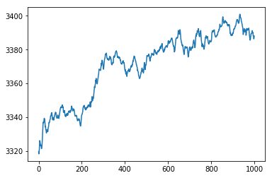

```python
temp=data.iloc[0:1000]
plt.plot(range(len(temp['close'])),temp['close'])
plt.show()
```

### 2.1 The normalization method is important

**Normally, we will do mean-std normalization 【new_x=(x-mean)/std】. It's most frequently used.**

```python
def mean_std_normalization_point(raw_data):

    #use t to predict t+look
    look=1
    #mean-std normalization, input 10 points predict 1 points
    #eg, in: x1-x10, out: x11, and x11 will be useful.
    train_rate=0.75
    raw_data=pd.DataFrame(raw_data['close'])
    raw_data=raw_data.dropna()
    raw_data=raw_data[raw_data['close']>0]
    raw_data=list(raw_data['close'])

    #get the mean and std
    raw_data=raw_data[:1000]
    basic_sample=raw_data[:int(len(raw_data)*train_rate)]
    avg=np.mean(basic_sample[:int(len(basic_sample)*train_rate)])
    std=np.std(basic_sample[:int(len(basic_sample)*train_rate)])

    #mean-std standardlization
    raw_data=(raw_data-avg)/2/std
    if len(raw_data)%2==0:
        raw_data=raw_data
    else:
        raw_data=raw_data[1:]

    data=raw_data
    x=np.full([len(data)-200,22],np.nan)
    for i in range(100,len(data)-100):
        x[i-100,0:20]=np.array(data[i-20:i])
        x[i-100,20]=(data[i-1+look]-data[i-1])/data[i-1]
        x[i-100,21]=data[i-1+look]
        if data[i-1+look]-data[i-1]>=0:
            x[i-100,20]=int(1)
        else:
            x[i-100,20]=int(0)

    point=int(x.shape[0]*train_rate)
    train=x[:point,:].reshape(-1,22)
    test=x[point:,:].reshape(-1,22)
    x_train=train[:,0:20]
    y_train=train[:,20]
    x_test=test[:,0:20]
    y_test=test[:,20]
    lstm_train=train[:,21]
    lstm_test=test[:,21]
    #plt.plot(range(len(x)),x[:,21])
    return x_train,y_train,x_test,y_test,lstm_train,lstm_test


def mean_std_normalization_sequence(raw_data):

    #mean-std normalization, input 10 points predict 10 points,
    #eg, in: x1-x10, out: x2_x11, and x11 will be useful.
    train_rate=0.8
    raw_data=pd.DataFrame(raw_data['close'])
    raw_data=raw_data.dropna()
    raw_data=raw_data[raw_data['close']>0]
    raw_data=list(raw_data['close'])

    #get the mean and std
    raw_data=raw_data[:1000]
    basic_sample=raw_data[:int(len(raw_data)*train_rate)]
    avg=np.mean(basic_sample[:int(len(basic_sample)*train_rate)])
    std=np.std(basic_sample[:int(len(basic_sample)*train_rate)])

    #mean-std standardlization
    raw_data=(raw_data-avg)/2/std
    if len(raw_data)%2==0:
        raw_data=raw_data
    else:
        raw_data=raw_data[1:]

    data=raw_data
    x=np.full([len(data)-200,22],np.nan)
    for i in range(100,len(data)-100):
        x[i-100,0:10]=data[i-10:i]
        x[i-100,11]=(data[i-1+look]-data[i-1])/data[i-1]
        x[i-100,12:22]=data[i:i+10]
        if data[i-1+look]-data[i-1]>=0:
            x[i-100,10]=int(1)
        else:
            x[i-100,10]=int(0)

    point=int(x.shape[0]*train_rate)
    train=x[:point,:].reshape(-1,22)
    test=x[point:,:].reshape(-1,22)
    x_train=train[:,0:10]
    y_train=train[:,10]
    x_test=test[:,0:10]
    y_test=test[:,10]
    lstm_train=train[:,12:22]
    lstm_test=test[:,12:22]

    #plt.plot(range(len(x)),x[:,21])
    return x_train,y_train,x_test,y_test,lstm_train,lstm_test
```

**However, I have seen some people do ret normalization 【new_x=x / x[0]】，which is much less frequently used. But it's intuitive and reasonable.** Here. I want to explain more for this expression. In every sample, we may have 30 points in sample, and 1 points out of sample. For each sample, we calculate the x_new[i]=x[i] / x[0].

```python
def ret_normalization_point(raw_data):

    #use t to predict t+look
    look=1
    #ret normalization, input 10 points predict 1 points
    #eg, in: x1-x10, out: x11, and x11 will be useful.
    train_rate=0.75
    raw_data=pd.DataFrame(raw_data['close'])
    raw_data=raw_data.dropna()
    raw_data=raw_data[raw_data['close']>0]
    raw_data=list(raw_data['close'])

    #get the mean and std
    raw_data=raw_data[:1000]
    basic_sample=raw_data[:int(len(raw_data)*train_rate)]
    avg=np.mean(basic_sample[:int(len(basic_sample)*train_rate)])
    std=np.std(basic_sample[:int(len(basic_sample)*train_rate)])

    if len(raw_data)%2==0:
        raw_data=raw_data
    else:
        raw_data=raw_data[1:]

    data=raw_data
    x=np.full([len(data)-200,22],np.nan)
    for i in range(100,len(data)-100):
        x[i-100,0:20]=list(np.array(data[i-20:i])/data[i-20]-1)
        x[i-100,20]=(data[i-1+look]-data[i-1])/data[i-1]
        x[i-100,21]=data[i-1+look]/data[i-20]-1
        if data[i-1+look]-data[i-1]>=0:
            x[i-100,20]=int(1)
        else:
            x[i-100,20]=int(0)

    point=int(x.shape[0]*train_rate)
    train=x[:point,:].reshape(-1,22)
    test=x[point:,:].reshape(-1,22)
    x_train=train[:,0:20]
    y_train=train[:,20]
    x_test=test[:,0:20]
    y_test=test[:,20]
    lstm_train=train[:,21]
    lstm_test=test[:,21]
    #plt.plot(range(len(x)),x[:,21])
    return x_train,y_train,x_test,y_test,lstm_train,lstm_test


def ret_normalization_sequence(raw_data):

    #ret normalization, input 10 points predict 10 points,
    #eg, in: x1-x10, out: x2_x11, and x11 will be useful.
    train_rate=0.75
    raw_data=pd.DataFrame(raw_data['close'])
    raw_data=raw_data.dropna()
    raw_data=raw_data[raw_data['close']>0]
    raw_data=list(raw_data['close'])
    raw_data=raw_data[:1000]

    if len(raw_data)%2==0:
        raw_data=raw_data
    else:
        raw_data=raw_data[1:]

    data=raw_data
    x=np.full([len(data)-200,22],np.nan)
    for i in range(100,len(data)-100):
        x[i-100,0:10]=list(np.array(data[i-10:i])/data[i-10]-1)
        x[i-100,11]=(data[i-1+look]-data[i-1])/data[i-1]
        x[i-100,12:22]=np.array(data[i:i+10])/data[i-10]-1
        if data[i-1+look]-data[i-1]>=0:
            x[i-100,10]=int(1)
        else:
            x[i-100,10]=int(0)

    point=int(x.shape[0]*train_rate)
    train=x[:point,:].reshape(-1,22)
    test=x[point:,:].reshape(-1,22)
    x_train=train[:,0:10]
    y_train=train[:,10]
    x_test=test[:,0:10]
    y_test=test[:,10]
    lstm_train=train[:,12:22]
    lstm_test=test[:,12:22]

    #plt.plot(range(len(x)),x[:,21])
    return x_train,y_train,x_test,y_test,lstm_train,lstm_test
```

Here, I just give two normalization methods. Later on, I will show you the differences.

### 2.2 Dropout is necessary and tricky here

Here, I have shown you the choice of **mean-std normalization** and **ret-normalization**. And there is also **sequence to sequence** prediction and **sequence to point** prediction. And we still have the choice to do dropout. It's hardly to see in most unprofessional article. **And I want to stress that if you have not seen a man （A silly blog writer） use dropout to do LSTM prediction on Stock series, you defintely have no need to read it at all!**

**Without dropout:**

```python
import tensorflow as tf
import numpy as np
import matplotlib.pyplot as plt

def LSTM_drop_out(x_train,y_train,x_test,y_test,lstm_train,lstm_test):

    tf.reset_default_graph()
    np.random.seed(1)
    tf.set_random_seed(1)
    TIME_STEP = x_test.shape[1]
    INPUT_SIZE = 1
    CELL_SIZE = 200
    lstm_xtrain=x_train[-len(x_test):,:]
    lstm_ytrain=lstm_train[-len(x_test):]

    tf_x = tf.placeholder(tf.float32, [None, TIME_STEP, INPUT_SIZE])
    tf_y = tf.placeholder(tf.float32, [None, INPUT_SIZE])
    tf_is_training = tf.placeholder(tf.bool, None)

    # LSTM
    sess = tf.Session()
    with tf.variable_scope("lstm_cell_2"):
        cell = tf.contrib.rnn.BasicLSTMCell(num_units=CELL_SIZE)
        init_s_2 = cell.zero_state(batch_size=lstm_xtrain.shape[0], dtype=tf.float32)
        outputs_2, final_s_2 = tf.nn.dynamic_rnn(cell,tf_x,initial_state=init_s_2)
        l4 = tf.reshape(outputs_2, [-1, CELL_SIZE])
        l5 = tf.layers.dense(l4, INPUT_SIZE)
        #outs_1 = tf.reshape(l2, [-1, TIME_STEP, INPUT_SIZE])
        l7 = tf.reshape(l5,[-1,TIME_STEP])

    out1 = tf.layers.dense(l7, 1)
    loss1 = tf.losses.mean_squared_error(labels=tf_y, predictions=out1)
    optimizer1 = tf.train.AdamOptimizer(learning_rate=0.005,beta1=0.9,beta2=0.999)
    train_op1 = optimizer1.minimize(loss1)
    sess.run(tf.global_variables_initializer())

    for step in range(5000):

        if step==0:
            feed_dict = {tf_x: lstm_xtrain.reshape(-1,TIME_STEP,1),tf_y: lstm_ytrain.reshape(-1,INPUT_SIZE),tf_is_training: True}
        else:
            feed_dict = {tf_x: lstm_xtrain.reshape(-1,TIME_STEP,1),tf_y: lstm_ytrain.reshape(-1,INPUT_SIZE),init_s_2: final_s_2_,tf_is_training: True}

        _, pred_train, los,final_s_2_= sess.run([train_op1, out1, loss1,final_s_2], feed_dict)
        if step%500==0:
            print('Current step: %s, current los: %s'%(str(step),str(los)))

    feed_dict = {tf_x: x_test.reshape(-1,TIME_STEP,1),tf_y: lstm_test.reshape(-1,INPUT_SIZE),init_s_2: final_s_2_,tf_is_training: False}
    _, pred_test, los,final_s_2_= sess.run([train_op1, out1, loss1,final_s_2], feed_dict)
    print('Test los '+str(los))

    count=0
    x=[]
    y1=[]
    y2=[]
    for i in range(len(pred_test)):
        if i==0:
            pass
        else:
            x.append(i)
            y1.append(lstm_test[i])
            y2.append(pred_test[i,0])
            if ((pred_test[i,0]-pred_test[i-1,0])>0)&(y_test[i]==1):
                count+=1
            elif ((pred_test[i,0]-pred_test[i-1,0])<=0)&(y_test[i]==0):
                count+=1

    acc=count/len(pred_test)
    plt.plot(range(len(lstm_ytrain)),lstm_ytrain,label='Train_real')
    plt.plot(range(len(lstm_ytrain)),pred_train,label='Train_predict')
    plt.plot(range(len(lstm_ytrain),len(lstm_ytrain)+len(y1)),y1,label='Test_real')
    plt.plot(range(len(lstm_ytrain),len(lstm_ytrain)+len(y2)),y2,label='Test_predict')
    plt.title("Figure1: Non-dropout_mean-std-normalization_s2p")
    plt.legend(loc='upper left')
    plt.show()
    print("Test classification accuracy is %s."%str(acc))

x_train,y_train,x_test,y_test,lstm_train,lstm_test=mean_std_normalization_point(data)
LSTM_drop_out(x_train,y_train,x_test,y_test,lstm_train,lstm_test)
```

[output not shown]

[output not shown]

**With dropout:**

**keep_rate = tf.placeholder(tf.float32, 1.0)**

This step can help us to do dropout in train set, but doesn't do so in testing sets. When keep_rate=1.0, we don't do dropout, when keep_rate=0.8, we do dropout. **Normally, we should not do dropout in testing sets. But many blog writer ignores it！**

```
Current step: 0, current los: 0.39796498
Current step: 500, current los: 0.008759445
Current step: 1000, current los: 0.009241226
Current step: 1500, current los: 0.005230332
Current step: 2000, current los: 0.001393049
Current step: 2500, current los: 0.0011114607
Current step: 3000, current los: 0.0012427284
Current step: 3500, current los: 0.00078455644
Current step: 4000, current los: 0.0007502492
Current step: 4500, current los: 0.00080242887
Test los 0.011080236
```

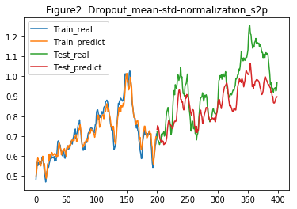

```
Test classification accuracy is 0.53.
```

```python
import tensorflow as tf
import numpy as np
import matplotlib.pyplot as plt

def LSTM_drop_out(x_train,y_train,x_test,y_test,lstm_train,lstm_test):

    tf.reset_default_graph()
    np.random.seed(1)
    tf.set_random_seed(1)
    TIME_STEP = x_test.shape[1]
    INPUT_SIZE = 1
    CELL_SIZE = 200
    lstm_xtrain=x_train[-len(x_test):,:]
    lstm_ytrain=lstm_train[-len(x_test):]

    tf_x = tf.placeholder(tf.float32, [None, TIME_STEP, INPUT_SIZE])
    tf_y = tf.placeholder(tf.float32, [None, INPUT_SIZE])
    #this step can help us to do dropout in train set, but doesn't do so in testing sets.
    keep_rate = tf.placeholder(tf.float32, 1.0)
    tf_is_training = tf.placeholder(tf.bool, None)

    # LSTM
    sess = tf.Session()
    with tf.variable_scope("lstm_cell_2"):
        cell = tf.contrib.rnn.BasicLSTMCell(num_units=CELL_SIZE)
        cell = tf.nn.rnn_cell.DropoutWrapper(cell, input_keep_prob=1.0, output_keep_prob=keep_rate[0],state_keep_prob=1.0)
        init_s_2 = cell.zero_state(batch_size=lstm_xtrain.shape[0], dtype=tf.float32)
        outputs_2, final_s_2 = tf.nn.dynamic_rnn(cell,tf_x,initial_state=init_s_2)
        l4 = tf.reshape(outputs_2, [-1, CELL_SIZE])
        l5 = tf.layers.dense(l4, INPUT_SIZE)
        #outs_1 = tf.reshape(l2, [-1, TIME_STEP, INPUT_SIZE])
        l7 = tf.reshape(l5,[-1,TIME_STEP])


    #for the last layer, I didn't recommand add a dropout layer
    out1 = tf.layers.dense(l7, 1)
    loss1 = tf.losses.mean_squared_error(labels=tf_y, predictions=out1)
    optimizer1 = tf.train.AdamOptimizer(learning_rate=0.005,beta1=0.9,beta2=0.999)
    train_op1 = optimizer1.minimize(loss1)
    sess.run(tf.global_variables_initializer())

    for step in range(5000):

        if step==0:
            feed_dict = {tf_x: lstm_xtrain.reshape(-1,TIME_STEP,1),tf_y: lstm_ytrain.reshape(-1,INPUT_SIZE),keep_rate:np.array([0.8]),tf_is_training: True}
        else:
            feed_dict = {tf_x: lstm_xtrain.reshape(-1,TIME_STEP,1),tf_y: lstm_ytrain.reshape(-1,INPUT_SIZE),init_s_2: final_s_2_,keep_rate:np.array([0.8]),tf_is_training: True}

        _, pred_train, los,final_s_2_= sess.run([train_op1, out1, loss1,final_s_2], feed_dict)
        if step%500==0:
            print('Current step: %s, current los: %s'%(str(step),str(los)))


    feed_dict = {tf_x: x_test.reshape(-1,TIME_STEP,1),tf_y: lstm_test.reshape(-1,INPUT_SIZE),init_s_2: final_s_2_,keep_rate:np.array([1.0]),tf_is_training: False}
    _, pred_test, los,final_s_2_= sess.run([train_op1, out1, loss1,final_s_2], feed_dict)
    print('Test los '+str(los))

    count=0
    x=[]
    y1=[]
    y2=[]
    for i in range(len(pred_test)):
        if i==0:
            pass
        else:
            x.append(i)
            y1.append(lstm_test[i])
            y2.append(pred_test[i,0])
            if ((pred_test[i,0]-pred_test[i-1,0])>0)&(y_test[i]==1):
                count+=1
            elif ((pred_test[i,0]-pred_test[i-1,0])<=0)&(y_test[i]==0):
                count+=1

    acc=count/len(pred_test)

    plt.plot(range(len(lstm_ytrain)),lstm_ytrain,label='Train_real')
    plt.plot(range(len(lstm_ytrain)),pred_train,label='Train_predict')
    plt.plot(range(len(lstm_ytrain),len(lstm_ytrain)+len(y1)),y1,label='Test_real')
    plt.plot(range(len(lstm_ytrain),len(lstm_ytrain)+len(y2)),y2,label='Test_predict')
    plt.title("Figure2: Dropout_mean-std-normalization_s2p")
    plt.legend(loc='upper left')
    plt.show()
    print("Test classification accuracy is %s."%str(acc))

x_train,y_train,x_test,y_test,lstm_train,lstm_test=mean_std_normalization_point(data)
LSTM_drop_out(x_train,y_train,x_test,y_test,lstm_train,lstm_test)
```

**Here, we can draw two conclusions:**

1. For stock time series problem, we should deal with high level of noise. Thus, we extrmelly need dropout and other tools, such as L1, L2 Generalization.
2. In both these two experimens, the fiiting performance is good. However, it doesn't tell the tendency. We don't know whether the price will rise in the next minutes, which is useless. Thus, we should explore more deeply in this field.

### 2.3 Deceptive performance or predictive performance

**Deceptive performance** means we get a good fitting performance, but it can not tell the tendency, which is useless for equity trading. I (also many researchers and smart blog writers) think the deceptive performance caused by the equilibrium the network can reach. To make some differences in this equilibrium, maybe we can compare the **sequence2sequence** methods with **sequence2point** methods.

```
Current step: 0, current los: 0.4193574
Current step: 500, current los: 0.0101423515
Current step: 1000, current los: 0.0098851165
Current step: 1500, current los: 0.00990758
Current step: 2000, current los: 0.009446282
Current step: 2500, current los: 0.009474265
Current step: 3000, current los: 0.009292026
Current step: 3500, current los: 0.009761258
Current step: 4000, current los: 0.009505761
Current step: 4500, current los: 0.009228671
Test los 0.047062125
```

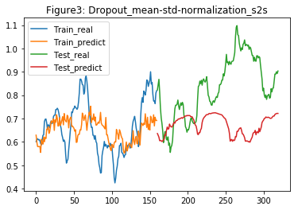

```
Test classification accuracy is 0.59375.
```

```python
import tensorflow as tf
import numpy as np
import matplotlib.pyplot as plt

#Here, we use same dropout methods and nomalization methods, but only change the s2s methods.
#input:x1-x10, output:x2-x11, x11 is what we want.
def LSTM_drop_out(x_train,y_train,x_test,y_test,lstm_train,lstm_test):

    tf.reset_default_graph()
    TIME_STEP = x_test.shape[1]
    INPUT_SIZE = 1
    CELL_SIZE = 200
    lstm_xtrain=x_train[-len(x_test):,:]
    lstm_ytrain=lstm_train[-len(x_test):,:]
    tf_x = tf.placeholder(tf.float32, [None, TIME_STEP, INPUT_SIZE])
    tf_y = tf.placeholder(tf.float32, [None, TIME_STEP])
    keep_rate = tf.placeholder(tf.float32, 1.0)
    tf_is_training = tf.placeholder(tf.bool, None)

    # LSTM
    sess = tf.Session()
    with tf.variable_scope("lstm_cell_1"):
        cell = tf.contrib.rnn.BasicLSTMCell(num_units=CELL_SIZE)
        cell = tf.nn.rnn_cell.DropoutWrapper(cell, input_keep_prob=1.0, output_keep_prob=keep_rate[0],state_keep_prob=keep_rate[0])
        init_s_2 = cell.zero_state(batch_size=lstm_xtrain.shape[0], dtype=tf.float32)
        outputs_2, final_s_2 = tf.nn.dynamic_rnn(cell,tf_x,initial_state=init_s_2)
        l4 = tf.reshape(outputs_2, [-1, CELL_SIZE])
        l5 = tf.layers.dense(l4, INPUT_SIZE)
        out1 = tf.reshape(l5,[-1,TIME_STEP])

    loss1 = tf.losses.mean_squared_error(labels=tf_y, predictions=out1)
    optimizer1 = tf.train.AdamOptimizer(learning_rate=0.005,beta1=0.9,beta2=0.999)
    train_op1 = optimizer1.minimize(loss1)
    sess.run(tf.global_variables_initializer())

    for step in range(5000):

        if step==0:
            feed_dict = {tf_x: lstm_xtrain.reshape(-1,TIME_STEP,1),tf_y: lstm_ytrain.reshape(-1,TIME_STEP),keep_rate:np.array([0.8]),tf_is_training: True}
        else:
            feed_dict = {tf_x: lstm_xtrain.reshape(-1,TIME_STEP,1),tf_y: lstm_ytrain.reshape(-1,TIME_STEP),init_s_2: final_s_2_,keep_rate:np.array([0.8]),tf_is_training: True}

        _, pred_train, los,final_s_2_= sess.run([train_op1, out1, loss1,final_s_2], feed_dict)
        if step%500==0:
            print('Current step: %s, current los: %s'%(str(step),str(los)))

    feed_dict = {tf_x: x_test.reshape(-1,TIME_STEP,1),tf_y: lstm_test.reshape(-1,TIME_STEP),init_s_2: final_s_2_,keep_rate:np.array([1.0]),tf_is_training: False}
    _, pred_test, los,final_s_2_= sess.run([train_op1, out1, loss1,final_s_2], feed_dict)
    print('Test los '+str(los))

    plt.plot(range(len(lstm_ytrain)),lstm_ytrain[:,-1],label='Train_real')
    plt.plot(range(len(lstm_ytrain)),pred_train[:,-1],label='Train_predict')
    plt.plot(range(len(lstm_ytrain),len(lstm_ytrain)+len(lstm_test)),lstm_test[:,-1],label='Test_real')
    plt.plot(range(len(lstm_ytrain),len(lstm_ytrain)+len(lstm_test)),pred_test[:,-1],label='Test_predict')
    plt.title("Figure3: Dropout_mean-std-normalization_s2s")
    plt.legend(loc='upper left')
    plt.show()

    count=0
    for i in range(len(pred_test)):
        if i==0:
            pass
        else:
            if ((pred_test[i,-1]-pred_test[i,-2])>0)&(y_test[i]==1):
                count+=1
            elif ((pred_test[i,-1]-pred_test[i,-2])<=0)&(y_test[i]==0):
                count+=1

    acc=count/len(pred_test)
    print("Test classification accuracy is %s."%str(acc))

x_train,y_train,x_test,y_test,lstm_train,lstm_test=mean_std_normalization_sequence(data)
LSTM_drop_out(x_train,y_train,x_test,y_test,lstm_train,lstm_test)
```

1. But we can't just draw these conclusions simply, we still need to repeat this experimens on different periods of time.
2. Sequence2Sequence is better, I think, it possibly this methods use more information and use sequence match to draw the network to reach a good equilibrium. But it's just my guess, it's really hard to varify my guess.

### 2.4 Final Match

```
Current step: 0, current los: 1.4529359e-06
Current step: 500, current los: 1.5094076e-06
Current step: 1000, current los: 1.1199342e-06
Current step: 1500, current los: 9.874395e-07
Current step: 2000, current los: 1.1383014e-06
Current step: 2500, current los: 1.0602461e-06
Current step: 3000, current los: 9.330217e-07
Current step: 3500, current los: 9.050473e-07
Current step: 4000, current los: 1.0421683e-06
Current step: 4500, current los: 9.813804e-07
Test los 1.1749358e-06
```

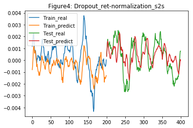

```
Test classification accuracy is 0.595.
```

```python
import tensorflow as tf
import numpy as np
import matplotlib.pyplot as plt

#Here, we use same dropout methods and nomalization methods, but only change the s2s methods.
#input:x1-x10, output:x2-x11, x11 is what we want.
def LSTM_drop_out(x_train,y_train,x_test,y_test,lstm_train,lstm_test):

    tf.reset_default_graph()
    TIME_STEP = x_test.shape[1]
    INPUT_SIZE = 1
    CELL_SIZE = 200
    lstm_xtrain=x_train[-len(x_test):,:]
    lstm_ytrain=lstm_train[-len(x_test):,:]
    tf_x = tf.placeholder(tf.float32, [None, TIME_STEP, INPUT_SIZE])
    tf_y = tf.placeholder(tf.float32, [None, TIME_STEP])
    keep_rate = tf.placeholder(tf.float32, 1.0)
    tf_is_training = tf.placeholder(tf.bool, None)

    # LSTM
    sess = tf.Session()
    with tf.variable_scope("lstm_cell_1"):
        cell = tf.contrib.rnn.BasicLSTMCell(num_units=CELL_SIZE)
        cell = tf.nn.rnn_cell.DropoutWrapper(cell, input_keep_prob=1.0, output_keep_prob=keep_rate[0],state_keep_prob=keep_rate[0])
        init_s_2 = cell.zero_state(batch_size=lstm_xtrain.shape[0], dtype=tf.float32)
        outputs_2, final_s_2 = tf.nn.dynamic_rnn(cell,tf_x,initial_state=init_s_2)
        l4 = tf.reshape(outputs_2, [-1, CELL_SIZE])
        l5 = tf.layers.dense(l4, INPUT_SIZE)
        out1 = tf.reshape(l5,[-1,TIME_STEP])

    loss1 = tf.losses.mean_squared_error(labels=tf_y, predictions=out1)
    optimizer1 = tf.train.AdamOptimizer(learning_rate=0.005,beta1=0.9,beta2=0.999)
    train_op1 = optimizer1.minimize(loss1)
    sess.run(tf.global_variables_initializer())

    for step in range(5000):

        if step==0:
            feed_dict = {tf_x: lstm_xtrain.reshape(-1,TIME_STEP,1),tf_y: lstm_ytrain.reshape(-1,TIME_STEP),keep_rate:np.array([0.8]),tf_is_training: True}
        else:
            feed_dict = {tf_x: lstm_xtrain.reshape(-1,TIME_STEP,1),tf_y: lstm_ytrain.reshape(-1,TIME_STEP),init_s_2: final_s_2_,keep_rate:np.array([0.8]),tf_is_training: True}

        _, pred_train, los,final_s_2_= sess.run([train_op1, out1, loss1,final_s_2], feed_dict)
        if step%500==0:
            print('Current step: %s, current los: %s'%(str(step),str(los)))

    feed_dict = {tf_x: x_test.reshape(-1,TIME_STEP,1),tf_y: lstm_test.reshape(-1,TIME_STEP),init_s_2: final_s_2_,keep_rate:np.array([1.0]),tf_is_training: False}
    _, pred_test, los,final_s_2_= sess.run([train_op1, out1, loss1,final_s_2], feed_dict)
    print('Test los '+str(los))

    plt.plot(range(len(lstm_ytrain)),lstm_ytrain[:,-1],label='Train_real')
    plt.plot(range(len(lstm_ytrain)),pred_train[:,-1],label='Train_predict')
    plt.plot(range(len(lstm_ytrain),len(lstm_ytrain)+len(lstm_test)),lstm_test[:,-1],label='Test_real')
    plt.plot(range(len(lstm_ytrain),len(lstm_ytrain)+len(lstm_test)),pred_test[:,-1],label='Test_predict')
    plt.title("Figure4: Dropout_ret-normalization_s2s")
    plt.legend(loc='upper left')
    plt.show()

    count=0
    for i in range(len(pred_test)):
        if i==0:
            pass
        else:
            if ((pred_test[i,-1]-pred_test[i,-2])>0)&(y_test[i]==1):
                count+=1
            elif ((pred_test[i,-1]-pred_test[i,-2])<=0)&(y_test[i]==0):
                count+=1

    acc=count/len(pred_test)
    print("Test classification accuracy is %s."%str(acc))

x_train,y_train,x_test,y_test,lstm_train,lstm_test=ret_normalization_sequence(data)
LSTM_drop_out(x_train,y_train,x_test,y_test,lstm_train,lstm_test)
```

**I stress that, financial problem is non-stationary, we should do a lot of experiments on different periods of time. And use the mean+-std to summarize the results. Don't just believe in others single experiment results!**

Due to the limitation of my laptop's jupyter notebook, I couldn't repeated all the experiments many times here. But I can tell you the personal findings here. **Dropout、Ret normalization and sequence2sequence is a good match.**

Also, **multi cells and tailored fully connected layers** will be helpful for this problem. These settings should be tuned accroding to the specific datasests. It takes time and seems trivial, but it will be really helpful.

## 3.Summary

1. Dropout、Ret normalization and sequence2sequence is a good match.
2. Don't be cheated by the fake equilibrium. Although the regression performance is good at a glance, the actual performance should be assessed by comparing with other regression methods. And the fake equilibrium can't tell the tendency. If we don't know tendency, it can't be helpful for our trading
3. Multi-cells and L1、L2 Generalization will also be helpful
4. Financial problem is difficult, it's non-stationary. You will get different performance in different period of time. You must repeat it many times to measure it. Don't do one experiment and make a conclusion. (The conclusions in this article were made by many trails in my Linux Server. I think it's realiable. But I just test on the latest 3 years A-share Index. Thus, these conclusions are still limited.)